# Simple Linear Regression Assignment

Zhe Jing Chin, id=22221970

15 November, 2022

## Predicting 3 km Running Times based on laboratory testing.

### Study Description:

Sixteen well-trained male middle and long distance runners performed a 3 km time trial and a number of running tests in the laboratory including their running velocity at a blood lactate concentration of 4 mmol.l-1 (v4mM). Other variables measured were running velocity at their Lactate Threshold (vTlac), and VO2 max. All the laboratory testing took place on a motorised treadmill, and distance running performance was determined by 3 km time trials on an indoor 200m track.

### Aims:

To investigate whether there is we can use linear regression to predict 3 km running time (minutes) from v-4mM (km per hour) in the population of well-trained male middle and long distance runners. Hence to predict 3km running time using running velocity at blood lactate concentration 4 mmol per litre.

- Response Variable: 3km running time (`Running.Time`) measured in minutes
- Explanatory Variable: running velocity at blood lactate concentration at 4mmol per litre (`v4mM`) measured in km/hr

```r
library(tidyverse)
```

### Read the data and see a few rows

```r
running = read.csv("3krunning.csv", header = TRUE)
head(running)
```

```
##   Running.Time v4mM vTlac Rel.14.5 Rel.16.1 VO2Max
## 1         8.23 20.4  19.5     47.1     52.4   23.4
## 2         8.30 19.5  18.2     48.1     60.0   23.5
## 3         8.62 19.0  17.3     50.3     56.8   22.0
## 4         8.82 18.9  17.8     51.8     56.1   23.0
## 5         9.18 17.8  16.5     48.7     54.1   21.5
## 6         9.23 17.2  15.6     50.5     59.6   20.5
```

### Summary Statistics

Task: Calculate the summary statistics for each column in the data and describe the key features of the data.

```r
running %>%
            summarize(Mean.v4mM = mean(v4mM),
                      SD.v4mM = sd(v4mM),
                      Mean.runningTime = mean(Running.Time),
                      SD.runningTime = sd(Running.Time))
```

```
##   Mean.v4mM  SD.v4mM Mean.runningTime SD.runningTime
## 1  17.06875 1.848141         9.458125       0.744269
```

The observations have an average 3km running time of 9.46 minutes, and an average running velocity at blood lactate concentration 4 mmol per litre at nearly 17.07 km/h. With the small standard deviation for both, the observations are clustered around the mean.

### Scatterplot

Task: Make a labelled scatterplot of `v4mM` vs `Running.Time` and interpret it.

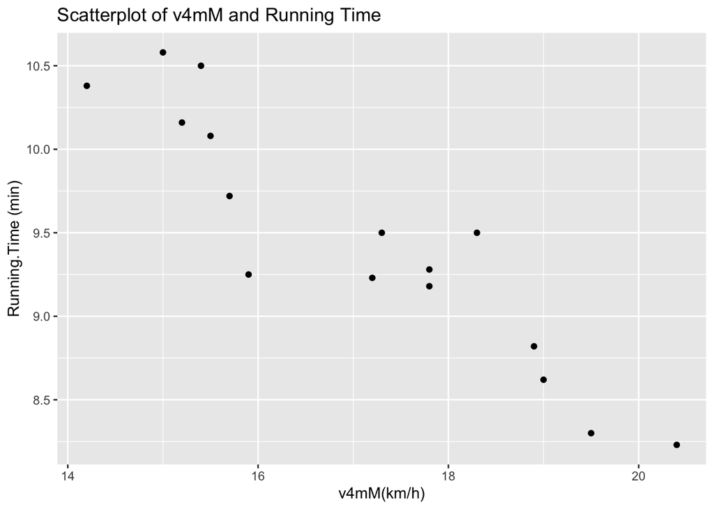

```r
ggplot(running, aes(y = Running.Time, x = v4mM)) +
  geom_point() +
  labs(y = "Running.Time (min)", x = "v4mM(km/h)",
       title = "Scatterplot of v4mM and Running Time")
```

It seems like a strong but negative relationship between the running time and v4mM.

### Scatterplot with smoother.

Task: Add a smooth line to the scatter plot produced in the previous task, and include the new plot below.

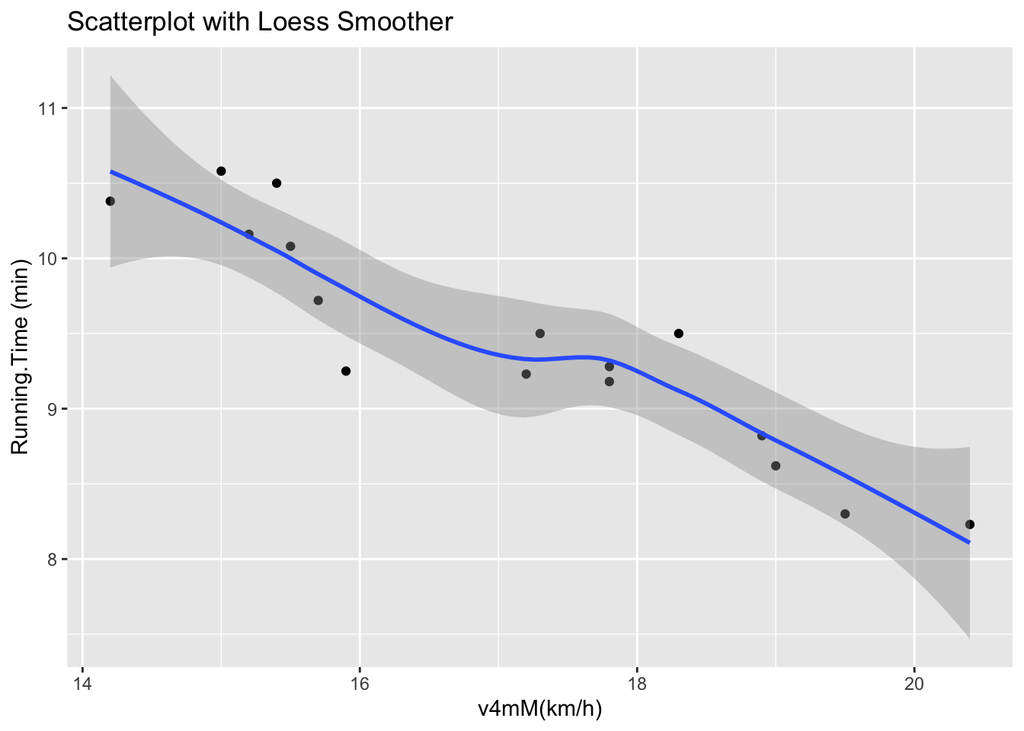

```r
ggplot(running, aes(x = v4mM, y = Running.Time)) +
  geom_point() +
  geom_smooth() +
  labs(y = "Running.Time (min)", x = "v4mM(km/h)",
       title = "Scatterplot with Loess Smoother")
```

Task: What does the smoother suggest regarding the suitability of a simple linear regression model for this relationship?

As the smoother is fairly a linear, thus it is suitable to perform a simple linear regression model in this application.

### Correlation coefficient

Task: calculate the correlation coefficient between `v4mM` vs `Running.Time` and interpret it.

```r
running %>% select (Running.Time, v4mM) %>% cor()
```

```
##              Running.Time      v4mM
## Running.Time     1.000000 -0.925857
## v4mM            -0.925857  1.000000
```

A strong negative correlation coefficient of 0.926 is found between the variables. As the value of v4mM decreases, the value of running time increases.

### Scatterplot with line of best fit

Task: Add the line of best fit to the scatter plot produced above and interpret it.

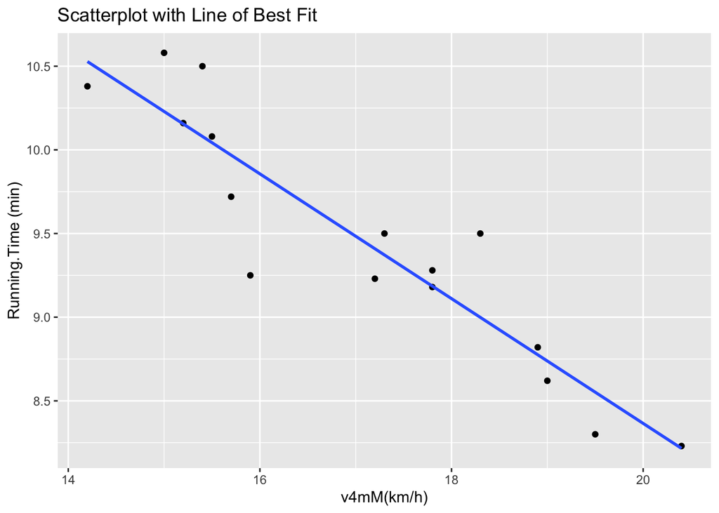

```r
ggplot(running, aes(x = v4mM, y = Running.Time)) +
  geom_point() +
  geom_smooth(method = "lm", se = FALSE) +
  labs(y = "Running.Time (min)", x = "v4mM(km/h)",
       title = "Scatterplot with Line of Best Fit")
```

The best fit line supports the assumption made previously, showing a strong but negative linear relationship between the dependent and independent variable.

### Fitting a Simple Linear Regression Model

Task: Estimate the parameters of the line of best fit for the linear relationship between 3 km running time and v-4mM in the sample. This can then be used for inference about the linear relationship in the population of well-trained male middle and long distance runners.

```r
running.model = lm(Running.Time ~ v4mM, running)
running.model
```

```
##
## Call:
## lm(formula = Running.Time ~ v4mM, data = running)
##
## Coefficients:
## (Intercept)         v4mM
##     15.8223      -0.3729
```

### Equation of line of best fit

Task: Write down the equation of the line of best fit and also provide an interpretation of the slope and intercept. Does the intercept have a physically meaningful interpretation?

Mean Running Time = 15.8223 + (-0.3729) * v4mM

Slope: A slope of -0.3729 represents the estimated change in running time for every increase of 1 km/h of v4mM. Intercept: If the v4mM is 0km/h, then the model predicts that the running time is approximately 15.8223 minutes

The intercept has no physically meaningful interpretation as a running velocity of 0km/h, or x=0 is not within the scope of observation since no one hasa velocity of 0km/h.

### Make some point predictions

Task: Predict the running time (i.e. `Running.Time`) when running speed at blood lactate concentration 4 mmol/litre (i.e. `v4mM`) are 14, 15, 16, 17, 18, 19 and 20 km per hour.

```r
v4mM_new = data.frame(
  v4mM = c(14, 15, 16, 17, 18, 19, 20)
)
```

```r
predict(running.model, newdata = v4mM_new, interval = "confidence")
```

```
##         fit       lwr       upr
## 1 10.602320 10.292450 10.912191
## 2 10.229467  9.990868 10.468065
## 3  9.856613  9.674799 10.038426
## 4  9.483759  9.327551  9.639966
## 5  9.110905  8.934940  9.286869
## 6  8.738051  8.508390  8.967712
## 7  8.365197  8.065626  8.664767
```

The confidence interval reflects the uncertainty around the mean predictions. As default, a 95% confidence interval is calculated.

fit: the predicted running time for the 7 new v4mM. lwr / upr: the lower and upper confidence limits for the expected values, respectively.

For example, the 95% confidence interval associated with a v4mM of 14km/h is (10.292450, 10.912191) minutes. This means that, according to our model, a running velocity at blood lactate concentration 4 mmol per litre of 14 km/h has, on average, a running time ranging between 10.29 and 10.91 minutes.

### Interval estimation for predicted running times

For each of the predictions produce a 95% confidence interval and 95% prediction interval, and interpret the results carefully.

```r
predict(running.model, newdata = v4mM_new, interval = "prediction")
```

```
##         fit      lwr       upr
## 1 10.602320 9.905285 11.299356
## 2 10.229467 9.561059 10.897874
## 3  9.856613 9.206309 10.506916
## 4  9.483759 8.840144 10.127373
## 5  9.110905 8.462212  9.759598
## 6  8.738051 8.072781  9.403320
## 7  8.365197 7.672678  9.057715
```

The prediction interval gives uncertainty around a single value.As default, a 95% prediction interval is calculated.

fit: the predicted running time for the 7 new v4mM. lwr / upr: the lower and upper prediction limits for the expected values, respectively.

For example, the 95% prediction interval associated with a v4mM of 14km/h is (9.905285, 11.299356) minutes. This means that, according to our model, 95% of a running velocity at blood lactate concentration 4 mmol per litre of 14 km/h have a running time ranging between 9.91 and 11.30 minutes.

The difference between CI and PI is that PI reflects uncertainty around a single value while CI reflects the uncertainty around the mean prediction values, hence PI normally has wider range than CI.

### Plots with confidence and prediction intervals

Task: Add the 95% confidence and 95% prediction intervals to the scatter plot with the line of best fit, and interpret.

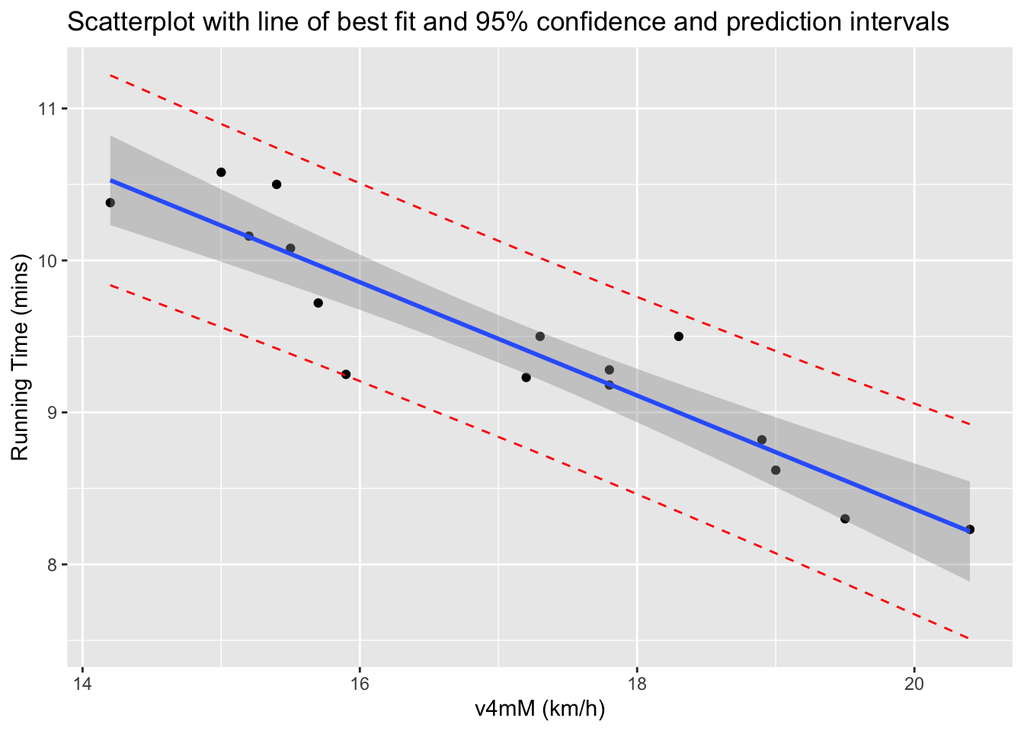

```r
pred.int = predict(running.model, newdata = running, interval = "prediction")

running2 = cbind(running, pred.int) # store predictions alongside original dataset

ggplot(running2, aes(y = Running.Time, x = v4mM)) +
  geom_point() +
  stat_smooth(method = lm) + # this includes a confidence interval
  geom_line(aes(y = lwr), color = "red", linetype = "dashed") + #  Add prediction intervals
  geom_line(aes(y = upr), color = "red", linetype = "dashed") +
  labs(x = "v4mM (km/h)", y = "Running Time (mins)",
       title = "Scatterplot with line of best fit and 95% confidence and prediction intervals")
```

The plot shows that at each given v4mM, there is 95% of the running time fall between the red-dash lines. It also shows that PI has wider range than CI.

### More prediction

Task: Predict the running time (i.e. `Running.Time`) when running speed at blood lactate concentration 4 mmol/litre (i.e. `v4mM`) is 18.9 km per hour.

```r
predict(running.model, newdata = data.frame(v4mM = 18.9))
```

```
##        1
## 8.775336
```

When running speed at blood lactate concentration 4 mmol/litre (i.e. `v4mM`) is 18.9 km per hour, the running time is 8.78 minutes.

Task: Why is the result here is different from 8.82, the observed running time when running speed at blood lactate concentration 4 mmol/litre (`v4mM`) is 18.9 mmol.l-1? (see observation row 4)

The linear model contains residuals. The best fit line estimated by the linear model does not represent a perfect predicting algorithm but a line for which the sum of the squared residuals is the smallest. Thus, the prediction might differ from the actual value.

Task: Predict the running time (i.e. `Running.Time`) when `v4mM` is 2.6 km per hour. Explain if you have any concern related to this prediction.

```r
predict(running.model, newdata = data.frame(v4mM = 2.6))
```

```
##        1
## 14.85286
```

It is unreasonable as we are extrapolating beyond the data.

### Overall Conclusion

Task: State your overall conclusions from fitting a linear model for the relationship between 3k running time and the running speed at blood lactate concentration 4 mmol/litre.

There is a strong negative relationship between the 3k running time and the running speed at blood lactate concentration 4 mmol/litre. The linear model shows that when the running speed increases, the running time decreases. We could predict the running time that satisfy this equation: Mean Running Time = 15.8223 + (-0.3729) * v4mM. The predicted value might has residual (different between the prediction and actual value). However, it is not useful to predict an observation that is beyond the data.